# Dice example

Katie Thomas

9/1/2020

## Task

*Please write a program that simulates and outputs the result of 100 rolls of a fair 20-sided die. What is your estimate for the average of those roles (including the standard deviation of that estimated average)? What is your estimate for the expected value of a single roll of a 20-sided die (including the standard deviation of that expected value)? Briefly explain why the two estimates are or are not the same.*

## Simulating 100 dice rolls

The following code simulates 100 rolls of a fair, 20-sided die and stores the output in a vector called ‘sim’.

```r
#make vector of numbered die sides (1-20)
dice <- c(1:20)

#Monte Carlo simulation of 100 rolls of 20 sided die
sim <- sample(dice, size = 100, replace = TRUE)

#mean of simulated rolls
sim_mean <- mean(sim)

#standard deviation of simulated rolls
sim_sd <- sd(sim)
```

The mean of the 100 simulated rolls is 11.08 and the standard deviation is 5.53. The frequency distribution of the simulated rolls is visualized below, as well as the mean (sold line) and +/- 1 standard deviation from the mean (dotted lines).

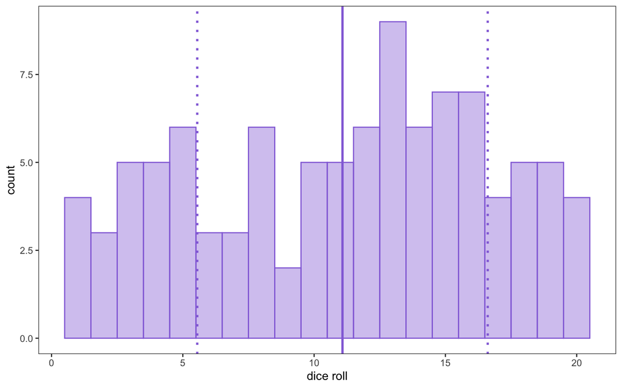

```r
#plot frequency distribution of simulated rolls
ggplot(as.data.frame(sim), aes(x=sim)) +
  geom_histogram(binwidth=1, color = "mediumpurple", fill = "mediumpurple", alpha = 0.4) +
  theme_bw() +
  theme(panel.grid.major = element_blank(), panel.grid.minor = element_blank()) +
  xlab("dice roll") +
  geom_vline(aes(xintercept=sim_mean),
            color="mediumpurple", linetype="solid", size=1) +
  geom_vline(aes(xintercept=sim_mean+sim_sd),
            color="mediumpurple", linetype="dotted", size=1) +
  geom_vline(aes(xintercept=sim_mean-sim_sd),
            color="mediumpurple", linetype="dotted", size=1)
```

## Expected value for a fair die

The expected value of a single die roll is the mean of the probability distributions. The code below calculates this for a fair, 20-sided die.

```r
#make vector of numbered dice sides (1-20)
dice <- c(1:20)

#set probability of rolling any one side on a fair-sided die
prob <- 1/length(dice)

#calculate mean of probability distribution
expected <- sum(dice*prob)

#calculate the variance
vnc <- sum(((dice-expected)^2)*prob)

#calculate standard deviation
stdev <- sqrt(vnc)
```

For a fair, 20-sided die the expected value is 10.5, and the standard deviation is 5.77.

## Comparison of estimates

The means for a simulation of 100 die rolls (mean = 11.08, SD = 5.53) is usually close, but slightly different, to the expected value (mean = 10.5, SD = 5.77). This is because the expected value is what we expect from extremely large (infinate) sample sizes. While 100 rolls is a decent sample size and usually yields a close approximation to the expected value, with larger and larger samples we would expect the mean to get closer to the expected value.

We can see this if we increase our sampling to 10,000 die rolls.

```r
#Monte Carlo simulation of 10,000 rolls of 20 sided die
sim2 <- sample(dice, size = 10000, replace = TRUE)

#mean of simulated rolls
sim2_mean <- mean(sim2)

#standard deviation of simulated rolls
sim2_sd <- sd(sim2)
```

In this simulation, the mean is 10.64 and the standard deviation is 5.66. This is generally closer to the expected value.